# 10 Estatinas e outros fármacos para modulação de lipoproteínas

Compreender a estrutura bioquímica e a função das lipoproteínas, como quilomícrons, lipoproteínas de densidade muito baixa (VLDL), lipoproteínas de baixa densidade (LDL) e lipoproteínas de alta densidade (HDL), é crucial para compreender o papel das estatinas no controle dos níveis de colesterol e na prevenção de doenças cardiovasculares. Essas lipoproteínas são essenciais para o transporte de colesterol e triglicérides na corrente sanguínea, e seu equilíbrio é vital para a saúde cardiovascular. As estatinas, como inibidores da biossíntese do colesterol, desempenham um papel significativo na modulação dessas lipoproteínas, reduzindo assim o risco de aterosclerose e doenças cardiovasculares relacionadas.

## 10.1 Bioquímica das lipoproteínas

### 10.1.1 Quilomícrons e VLDL

Quilomícrons são as maiores lipoproteínas, responsáveis principalmente pelo transporte de triglicérides e colesterol da dieta do intestino para outros tecidos. Eles são ricos em triglicérides e têm baixa densidade devido ao seu alto conteúdo lipídico.

VLDL é sintetizado no fígado e transporta triglicérides endógenos e colesterol para os tecidos periféricos. O VLDL é convertido em lipoproteínas de densidade intermediária (IDL) e, eventualmente, em LDL à medida que os triglicérides são removidos.

### 10.1.2 LDL e HDL

LDL, muitas vezes referido como “colesterol ruim”, é o principal transportador de colesterol no sangue. Níveis elevados de LDL estão associados a um risco aumentado de aterosclerose, pois o LDL pode depositar colesterol nas paredes arteriais, levando à formação de placas.

HDL, conhecido como “colesterol bom”, ajuda a remover o colesterol da corrente sanguínea e transportá-lo de volta ao fígado para excreção ou reutilização. Níveis mais altos de HDL estão associados a um risco reduzido de doenças cardiovasculares.

### 10.1.3 Colesterol e aterosclerose

O colesterol é um componente vital das membranas celulares e um precursor dos hormônios esteróides e dos ácidos biliares. No entanto, o colesterol excessivo, particularmente na forma de LDL, pode levar à aterosclerose, uma condição caracterizada pelo acúmulo de placas ricas em colesterol nas paredes arteriais, aumentando o risco de ataques cardíacos e derrames.

## 10.2 Papel das estatinas

As estatinas são inibidores competitivos da enzima **HMG-CoA redutase**, que é crucial na via de biossíntese do colesterol. Ao inibir essa enzima, as estatinas reduzem efetivamente a produção de colesterol no fígado, levando a uma diminuição nos níveis circulantes de LDL.

As estatinas não apenas reduzem o colesterol LDL, mas também têm efeitos **pleiotrópicos**, como melhorar a função endotelial, reduzir a inflamação e estabilizar as placas ateroscleróticas, que contribuem para seus efeitos protetores cardiovasculares.

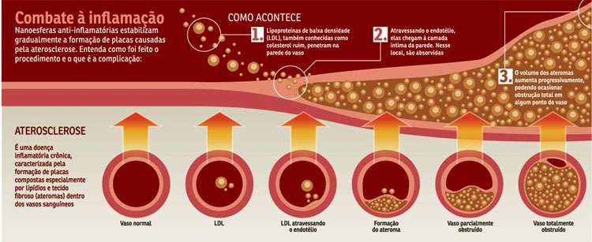

Figure 10.1: Formação do ateroma

### 10.2.1 Implicações clínicas

Foi demonstrado que as estatinas reduzem significativamente a incidência de eventos cardiovasculares em pacientes com níveis elevados de colesterol. Eles são particularmente eficazes em indivíduos com histórico de doenças cardiovasculares ou com alto risco.

A eficácia das estatinas na redução do colesterol LDL e seu perfil de segurança as tornam uma pedra angular no tratamento da hipercolesterolemia e na prevenção de doenças cardiovasculares.

Embora as estatinas sejam altamente eficazes no controle dos níveis de colesterol e na redução do risco cardiovascular, é importante considerar fatores individuais do paciente, como predisposições genéticas e possíveis interações medicamentosas, ao prescrever esses medicamentos. Além disso, modificações no estilo de vida, incluindo dieta e exercícios, continuam sendo componentes essenciais das estratégias de prevenção de doenças cardiovasculares. Compreender os aspectos bioquímicos e clínicos das lipoproteínas e estatinas fornece uma base para explorar suas descobertas e aplicações terapêuticas na química farmacêutica.

Foi demonstrado que as estatinas, conhecidas principalmente por seus efeitos na redução do colesterol, melhoram uma variedade de condições clínicas, particularmente aquelas relacionadas à saúde cardiovascular. Eles são amplamente utilizados na prevenção primária e secundária de doenças cardiovasculares (DCV), incluindo doença coronariana e acidente vascular cerebral isquêmico. No entanto, sua eficácia em condições não cardiovasculares continua sendo um tópico de pesquisas e debates contínuos. A incidência dessas condições varia globalmente, com dados específicos disponíveis para o Brasil, onde uma parcela significativa da população não atinge as metas de colesterol LDL apesar da terapia com estatinas. Esta visão geral explorará as condições melhoradas pelas estatinas, aquelas que não o são, e a incidência dessas condições em todo o mundo e no Brasil.

## 10.3 Condições melhoradas pelas estatinas

**Doenças cardiovasculares**: As estatinas são altamente eficazes na redução do risco de eventos coronarianos, derrames e mortalidade cardiovascular. Eles conseguem isso diminuindo o colesterol LDL e os triglicérides e aumentando o colesterol HDL. As estatinas foram associadas a uma redução de 22% no colesterol total e uma redução de 29% no colesterol LDL, reduzindo significativamente o risco relativo de eventos coronarianos e mortalidade cardiovascular.

**Efeitos pleiotrópicos**: Além da redução de lipídios, as estatinas melhoram a função endotelial, estabilizam as placas ateroscleróticas e reduzem o estresse oxidativo e a inflamação. Esses efeitos contribuem para a redução da morbidade e mortalidade em pacientes com DCV de alto risco.

**Condições não cardiovasculares**: Evidências emergentes sugerem que as estatinas podem beneficiar doenças como osteoporose, certos tipos de câncer, doenças renais e distúrbios neurológicos, como Alzheimer e Parkinson. No entanto, a evidência é mais robusta para algumas condições do que para outras.

As DCV continuam sendo a principal causa de mortalidade em todo o mundo e no Brasil. No Brasil, aproximadamente 5,8 milhões de pessoas no sistema público de saúde e 1,2 milhão no sistema suplementar estão sob prevenção secundária de eventos cardiovasculares. No entanto, 9% a 19% desses pacientes não atingem as metas de colesterol LDL com as terapias atuais, indicando a necessidade de intervenções adicionais.

No Brasil, a terapia com estatina em dose intermediária é considerada econômica e é priorizada para prevenir eventos cardiovasculares. Apesar das implicações financeiras, as estatinas são um componente crítico da estratégia brasileira de saúde pública contra as DCV.

Embora as estatinas sejam uma pedra angular no tratamento de doenças cardiovasculares, seu papel em condições não cardiovasculares ainda está sob investigação. A evidência de seus benefícios em resultados não relacionados a doenças cardiovasculares é menos conclusiva, e mais pesquisas são necessárias para estabelecer sua eficácia nessas áreas. No Brasil, o desafio continua sendo otimizar a terapia com estatinas para garantir que mais pacientes atinjam suas metas de colesterol LDL, reduzindo assim a carga de doenças cardiovasculares.

## 10.4 História do desenvolviemnto das Estatinas

A história das estatinas começou na década de 1970 com o cientista japonês Akira Endo, que conduziu uma busca sistemática por inibidores da enzima HMG-CoA redutase, identificada como o passo limitante na biossíntese do colesterol. Trabalhando com triagens de culturas microbianas, Endo isolou o primeiro composto desta classe, a compactina (também conhecida como mevastatina), a partir de fungos. Este descobrimento não foi acidental, mas sim o resultado de uma estratégia racional baseada nos avanços científicos da época sobre a via metabólica do colesterol e a compreensão emergente dos receptores de LDL e seu papel no risco aterosclerótico. A compactina demonstrou potente inibição da HMG-CoA redutase em modelos pré-clínicos, estabelecendo a prova de conceito de que esta abordagem farmacológica poderia reduzir efetivamente os níveis de colesterol plasmático.

O caminho do laboratório até a clínica foi longo e repleto de desafios. Em 1978, realizou-se o primeiro ensaio clínico em humanos com um inibidor de HMG-CoA redutase, mas a compactina não prosperou como candidato clínico definitivo, apesar de ter validado o alvo terapêutico. Paralelamente, a empresa farmacêutica Merck, liderada por pesquisadores como Alfred Alberts, isolou a lovastatina a partir do fungo *Aspergillus terreus* e levou-a através do desenvolvimento clínico até a aprovação regulatória. A lovastatina apresentava uma estrutura química muito semelhante à mevastatina, compartilhando o mesmo núcleo decalínico em forma de lactona, mas com pequenas diferenças na cadeia lateral que lhe conferiam propriedades farmacológicas distintas. A equipe da Merck, sob a liderança de pesquisadores como Alfred Alberts, conduziu extensos estudos pré-clínicos e clínicos que demonstraram a eficácia e segurança da lovastatina na redução do colesterol LDL. Este composto tornou-se o primeiro inibidor de HMG-CoA redutase aprovado para uso clínico, comercializado sob o nome Mevacor, marcando o início da era das estatinas como classe terapêutica estabelecida.

[figure not shown]

Figure 10.2: Akira Endo e a compactina e a Merk com a Lovastatina

### 10.4.1 Sinvastatina: A Otimização Semi-Sintética da Lovastatina

A sinvastatina (simvastatina) representa um marco importante na evolução das estatinas, sendo o primeiro derivado semi-sintético desenvolvido especificamente para melhorar as propriedades farmacológicas da lovastatina. A Merck realizou modificações químicas direcionadas na estrutura da lovastatina, alterando especificamente a porção lateral da molécula lactona enquanto preservava o núcleo decalínico essencial para a atividade inibitória. Esta modificação estrutural foi projetada com objetivos claros: aumentar a potência inibitória da enzima HMG-CoA redutase e otimizar o perfil farmacocinético, incluindo melhor absorção e distribuição tecidual. A transformação química manteve o mecanismo fundamental de ação — a conversão da forma lactona pró-fármaco ao ácido β-hidroxílico ativo que mimetiza o intermediário natural da enzima — mas resultou em um composto com maior lipofilia comparado à lovastatina. Esta maior lipofilia conferiu à sinvastatina uma capacidade aumentada de penetração em tecidos lipofílicos e atravessar barreiras celulares, o que se traduziu em diferenças tanto na eficácia quanto no perfil de efeitos adversos em comparação com sua molécula progenitora. A sinvastatina demonstrou ser mais potente que a lovastatina em estudos clínicos, consolidando-se como uma das estatinas mais prescritas mundialmente.

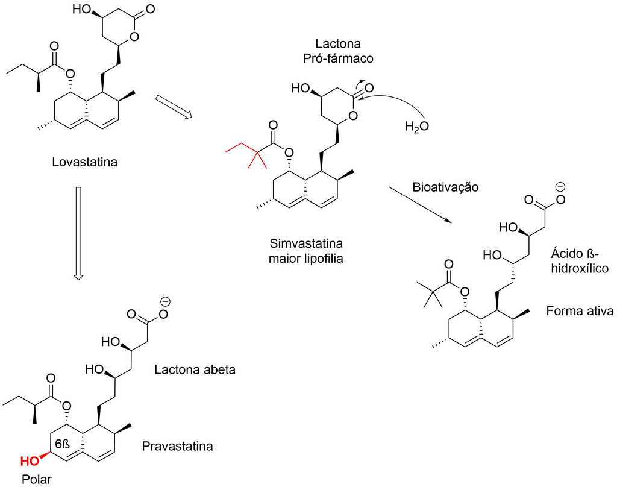

Figure 10.3: Estatina Sinvastatina sendo ativada por hidrólise do anel lactona e a Pravastatina

### 10.4.2 Pravastatina: A Via da Biotransformação Microbiana

O desenvolvimento da pravastatina seguiu uma rota tecnológica diferente, baseada em biotransformação microbiana ao invés de síntese química direta. Partindo da mevastatina (compactina) como substrato, pesquisadores — principalmente em empresas japonesas como a Sankyo — utilizaram micro-organismos específicos, notadamente *Streptomyces carbophilus*, para realizar uma hidroxilação seletiva no carbono **6β** do esqueleto decalínico. Esta modificação enzimática introduziu um grupo hidroxila adicional na molécula, resultando em propriedades farmacológicas substancialmente diferentes das estatinas lipofílicas. A pravastatina apresenta-se predominantemente na forma do ácido hidroxílico ativo, requerendo menor conversão metabólica comparada às lactonas pró-droga como lovastatina e sinvastatina. Sua característica mais distintiva é a maior hidrofilicidade, que resulta em menor distribuição para tecidos extra-hepáticos e maior seletividade hepática. Esta propriedade confere à pravastatina um perfil de segurança diferenciado, com menor potencial para certos efeitos adversos musculares e menos interações medicamentosas mediadas pelo sistema citocromo P450. O processo de produção industrial da pravastatina por bioconversão microbiana exigiu significativos avanços em engenharia de cepas e otimização de cultivos para viabilizar a produção em larga escala. A pravastatina foi lançada comercialmente pela Sankyo em 1989, tornando-se a primeira estatina hidrofílica disponível no mercado.

Embora as estatinas de primeira geração tenham sido inovadoras, o desenvolvimento de estatinas sintéticas forneceu opções adicionais para o controle do colesterol. As estatinas sintéticas, como atorvastatina e fluvastatina, oferecem diferentes perfis farmacocinéticos e potências, o que pode ser vantajoso em certos cenários clínicos. No entanto, o papel fundamental das estatinas de primeira geração na história das terapias para baixar o colesterol permanece significativo, pois elas abriram o caminho para o desenvolvimento de estatinas mais avançadas e potentes.

## 10.5 Estatinas de segunda geração (sintéticas)

A motivação para o design da **atorvastatina** (a primeira estatína do tipo 2) baseou-se na hipótese de que a complexa estrutura do anel dos metabólitos fúngicos poderia ser substituída por um “template” (molde) mais simples, desde que mantivesse duas características essenciais: a fração 3,5-di-hidroxi-heptanoato (que mimetiza o substrato da enzima) e um grupo lipofílico grande mantido na relação espacial correta. A equipe de descoberta da atorvastatina escolheu o sistema de anel 1H-pirrol como seu molde central. O desenvolvimento da estrutura-atividade (SAR) foi crucial; partindo de análogos mais simples , a **modelagem molecular** indicou a necessidade de ocupar mais espaço no sítio ativo. Isso levou à síntese de um pirrol pentassubstituído, culminando na estrutura final da atorvastatina (composto (+)-24), que possui grupos 2-(4-fluorofenil), 5-isopropil, 3-fenil e 4-fenilcarboxamida, sendo o estereoisômero (R,R) o responsável por sua alta potência.

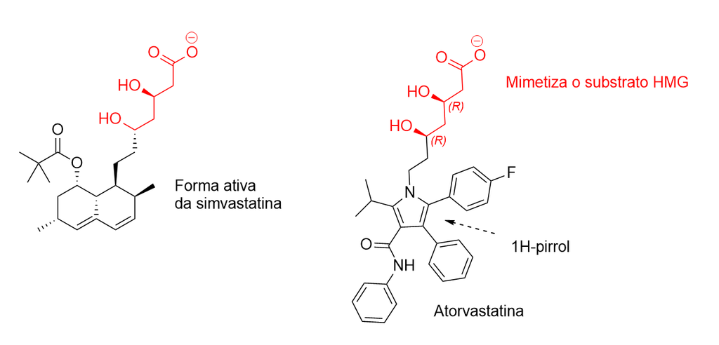

Figure 10.4: Atorvastatina e Sinvastatina ativada comparadas.

### 10.5.1 Fluvastatina

A fluvastatina, descoberta como um inibidor sintético da enzima HMG-CoA redutase, é utilizada para controlar a hipercolesterolemia e reduzir o risco cardiovascular. Desenvolvida nos anos 1980, a fluvastatina se destaca por sua eficácia na redução do colesterol LDL em cerca de 19-31% e do colesterol total em 15-21%, além de possuir um perfil de segurança favorável, com baixo risco de efeitos adversos severos como miopatia e rabdomiólise. Apresenta menor potencial para interações medicamentosas, sendo uma escolha segura para pacientes que usam múltiplos medicamentos, e ainda demonstra efeitos pleiotrópicos benéficos, como ação antiaterogênica, antitrombótica e antioxidante. Além disso, é considerada custo-efetiva em relação a outras estatinas. Suas limitações incluem potência menor comparada a estatinas mais recentes, uso restrito em pacientes de alto risco que necessitam de redução lipídica mais agressiva, e possível elevação das enzimas hepáticas, o que requer monitoramento. Essa combinação de benefícios e limitações faz da fluvastatina uma opção valiosa no manejo da dislipidemia e prevenção cardiovascular.

### 10.5.2 Controvérsia da Cerivastatina

A cerivastatina foi introduzida como a sexta estatina no mercado, conhecida por sua alta potência e lipofilicidade, o que permitiu que ela fosse eficaz em doses muito mais baixas em comparação com outras estatinas.

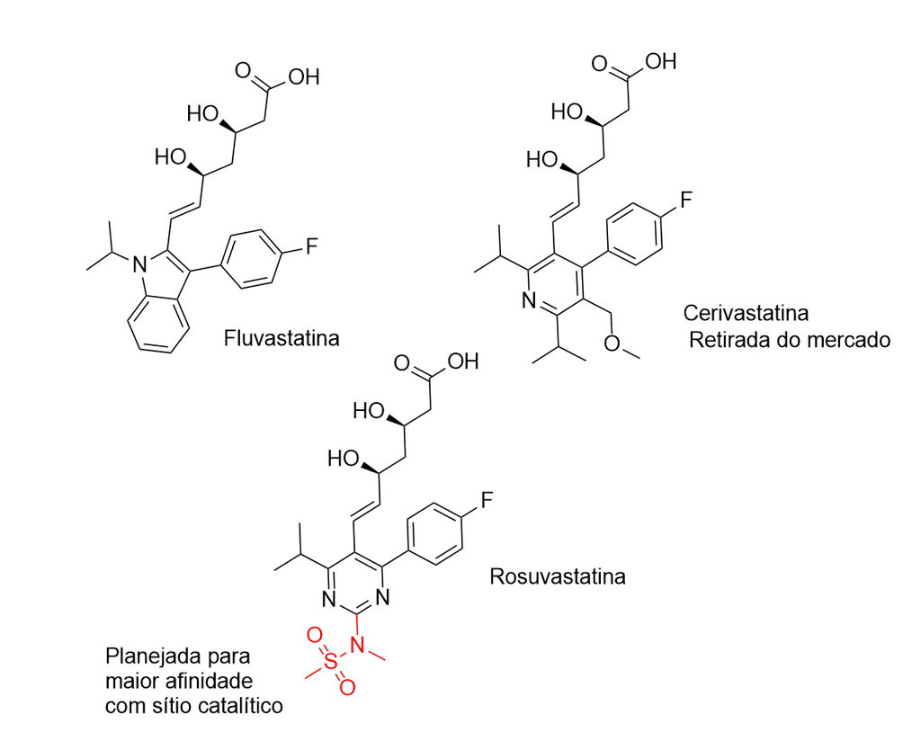

Foi inicialmente elogiado por sua eficácia farmacológica e perfil de segurança favorável, com uma alta biodisponibilidade de cerca de 60% após administração oral. O medicamento foi comercializado sob os nomes Baycol nos Estados Unidos e Lipobay na Europa.

A cerivastatina foi associada a uma incidência significativamente maior de rabdomiólise em comparação com outras estatinas, com o risco sendo 10 a 80 vezes maior. O risco de rabdomiólise foi particularmente alto em pacientes que tomaram a dose total de 0,8 mg/dia e aqueles que a usaram em combinação com gemfibrozil, um medicamento que pode aumentar os níveis sanguíneos de estatinas.

A retirada foi motivada por relatos de 52 mortes devido à rabdomiólise, levando à insuficiência renal. A Bayer, fabricante, retirou a cerivastatina do mercado em agosto de 2001, após relatos crescentes de efeitos adversos e fatalidades. A retirada da cerivastatina levou a preocupações mais amplas sobre a segurança de todas as estatinas, levando a revisões e atualizações das diretrizes clínicas sobre seu uso. O incidente destacou a importância de considerar as interações medicamentosas e os fatores de risco específicos do paciente, como idade, sexo e função renal, na terapia com estatinas. Ações legais ocorreram, com a Bayer sendo forçada a divulgar documentos revelando seu conhecimento dos riscos do medicamento antes de sua retirada.

O caso da cerivastatina ressaltou a necessidade de ensaios clínicos de longo prazo para avaliar a segurança e a eficácia dos medicamentos e também enfatizou a não intercambialidade das estatinas, pois as diferenças na farmacocinética e na potência podem levar a diferentes perfis de segurança.

Embora a retirada da cerivastatina tenha sido um revés, ela forneceu informações valiosas sobre a segurança e o monitoramento da terapia com estatinas. O incidente reforçou a importância da vigilância pós-comercialização e a necessidade de avaliações de risco abrangentes no desenvolvimento de medicamentos. Também destacou o potencial das estatinas de terem diversos efeitos além da redução do colesterol, o que poderia ser explorado em pesquisas futuras.

### 10.5.3 Rosuvastatina

A rosuvastatina foi desenvolvida pela empresa japonesa Shionogi e representa um marco importante na evolução das estatinas. Patenteada em 1991 e aprovada pela FDA em agosto de 2003, a rosuvastatina surgiu como uma estatina de terceira geração, beneficiando-se do conhecimento acumulado sobre o mecanismo de inibição da HMG-CoA redutase. Seu desenvolvimento foi impulsionado pela necessidade de criar um fármaco com maior potência e eficácia comparada às estatinas de primeira e segunda gerações, permitindo atingir metas terapêuticas mais agressivas no controle do colesterol LDL em pacientes de alto risco cardiovascular. A estrutura química da rosuvastatina foi otimizada para proporcionar uma interação mais eficiente com a enzima-alvo, resultando em um inibidor altamente seletivo e potente.

Os pontos fortes da rosuvastatina que a destacam entre as estatinas aprovadas residem principalmente em sua potência excepcional e perfil lipídico abrangente. Ela é capaz de reduzir o colesterol LDL em até 53% nas doses mais altas, superando as mesmas doses de atorvastatina e sendo significativamente mais potente que sinvastatina e pravastatina. Além da redução do LDL, a rosuvastatina apresenta efeitos amplos no perfil lipídico, aumentando o colesterol HDL (“bom”) em aproximadamente 15% e reduzindo triglicerídeos de forma mais eficaz que outras estatinas. Possui uma meia-vida de aproximadamente 19 horas, o que permite administração em qualquer horário do dia, diferentemente da sinvastatina, que deve ser tomada preferencialmente à noite. Adicionalmente, demonstra excelente eficácia na prevenção secundária de eventos cardiovasculares e estabilização de placas ateroscleróticas, além de apresentar menor interação medicamentosa com outros fármacos.

Contudo, apesar de suas vantagens, outras estatinas conservam benefícios importantes que as mantêm relevantes na prática clínica. A atorvastatina, por exemplo, possui potência comparável à rosuvastatina em doses equivalentes, com um perfil de segurança amplamente documentado por décadas de uso clínico, oferecendo maior tranquilidade em relação a efeitos adversos de longo prazo. A sinvastatina e pravastatina, embora menos potentes, apresentam custo-efetividade superior e menor incidência de certos efeitos colaterais em determinadas populações. Estudos recentes mostram que a rosuvastatina, apesar de mais potente na redução de LDL, foi associada a maior ocorrência de diabetes *de novo* e *cataratas* em algumas coortes, efeitos que as outras estatinas apresentam em menor proporção. Além disso, em termos econômicos, a fluvastatina mantém vantagem custo-benefício, sendo particularmente adequada para pacientes que requerem múltiplas associações medicamentosas. Portanto, embora a rosuvastatina represente o estado da arte em potência hipolipemiante, a escolha entre as estatinas deve considerar o perfil individual do paciente, segurança a longo prazo e custos associados.

## 10.6 Mecanismo de ação das estatinas

As estatinas exercem seu efeito hipolipemiante através de um mecanismo elegante e bem estabelecido que começa com a inibição direta da enzima HMG-CoA redutase, a etapa-chave na biossíntese de colesterol celular. Ao bloquear essa enzima, as estatinas impedem a conversão de HMG-CoA em mevalonato, reduzindo drasticamente a concentração de colesterol dentro das células. Essa diminuição intracelular de colesterol funciona como um sinal regulatório que dispara uma resposta coordenada: a célula aumenta a expressão gênica para sintetizar mais receptores de LDL, que são então transportados para a membrana plasmática. Esses receptores adicionais capturam ativamente as partículas de LDL circulantes no sangue, removendo-as da circulação e internalizando-as. Paralelamente, a redução da disponibilidade de colesterol intramembrana também diminui a capacidade das células de montar e secretar VLDL, outra lipoproteína aterógena.

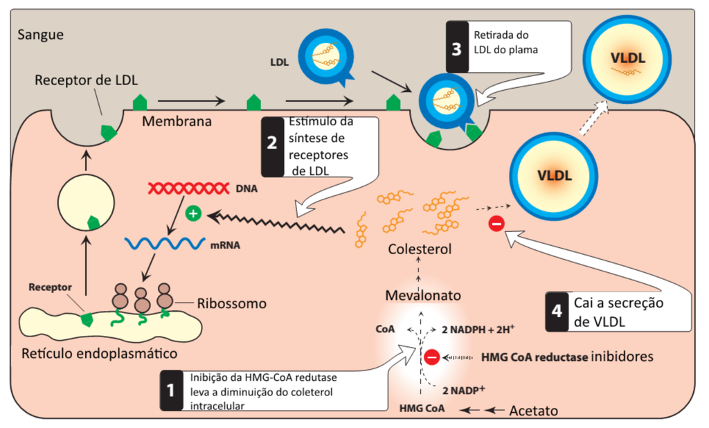

Figure 10.7: Aqui está uma legenda detalhada para a figura, explicando o mecanismo de ação dos inibidores da HMG-CoA redutase (estatinas): Mecanismo de Ação dos Inibidores da HMG-CoA Redutase (Estatinas) A figura ilustra como os inibidores da HMG-CoA redutase, como as estatinas, reduzem o colesterol no sangue através de quatro etapas principais: Inibição da Síntese de Colesterol: O inibidor bloqueia a enzima HMG-CoA redutase, uma etapa-chave na produção de colesterol. Isso impede a conversão de HMG-CoA em mevalonato e, consequentemente, diminui a quantidade de colesterol dentro da célula (colesterol intracelular). Estímulo da Síntese de Receptores de LDL: A célula detecta a baixa de colesterol intracelular. Como resposta, ela aumenta a expressão de genes (via DNA -> mRNA -> Ribossomos) que produzem mais receptores de LDL. Retirada de LDL do Plasma: Esses novos receptores de LDL migram para a superfície (membrana) da célula e capturam ativamente as partículas de LDL que estão circulando no sangue, movendo-as para dentro da célula. Isso resulta na diminuição do LDL no plasma. Redução da Secreção de VLDL: A menor disponibilidade de colesterol dentro da célula também diminui a capacidade da célula de montar e secretar VLDL (outra lipoproteína) no sangue. O efeito combinado é uma redução significativa dos níveis de LDL (“colesterol ruim”) e VLDL no sangue.

O resultado final desse mecanismo multifatorial é uma redução significativa e sustentada dos níveis plasmáticos de LDL (“colesterol ruim”) e VLDL, com reflexos positivos no perfil lipídico geral do paciente. Essa combinação de inibição de síntese, aumento da captação celular de lipoproteína e redução da secreção de VLDL explica por que as estatinas são tão eficazes na redução do risco cardiovascular. A figura apresenta essas quatro etapas principais de forma integrada, mostrando como cada componente do mecanismo contribui para o efeito terapêutico final. Esse entendimento molecular do seu funcionamento fundamenta o uso clínico das estatinas e sua posição privilegiada nas diretrizes de prevenção primária e secundária de doenças cardiovasculares.

### 10.6.1 Rabdomiólise

A rabdomiólise induzida por estatinas (statin-induced rhabdomyolysis) é uma complicação potencialmente fatal resultante de múltiplos mecanismos moleculares convergentes que afetam especificamente a musculatura esquelética, em contraste com o tecido cardíaco que raramente é acometido. Esse padrão de seletividade muscular esquelética oferece importantes pistas sobre os mecanismos envolvidos e, particularmente, sobre o papel central que a depleção de Coenzima Q10 (CoQ10) desempenha neste processo.

**Mecanismo 1: Depleção de Isoprenoides e Falha na Prenilação de GTPases Rho**

O bloqueio da HMG-CoA redutase não apenas reduz colesterol, mas também diminui drasticamente a síntese de intermediários upstream da via do mevalonato, incluindo ácido mevalônico e geranilgeranilpirofosfato (GGPP). Esses intermediários são substratos essenciais para a prenilação pós-traducional de proteínas Rho GTPases como RhoA e Rac1, que são fatores críticos para a regulação do citoesqueleto muscular, dinâmica de actina-miosina e função contrátil. A falha na geranilgeranilação dessas proteínas impede sua ativação e translocação para a membrana celular, resultando em desorganização do citoesqueleto e comprometimento da integridade estrutural e funcional da fibra muscular. Essa via é particular mente importante em células musculares, onde a organização precisa do citoesqueleto é absolutamente crítica, o que explica por que a musculatura esquelética é seletivamente afetada.

**Mecanismo 2: Depleção Profunda de Coenzima Q10 e Falha Mitocondrial** A via do mevalonato produz CoQ10 através de sequencial adição de unidades de isopreno (oriundas de GGPP derivado da rota dos isoprenoides) a um precursor benzoquinônico (para-hidroxibenzoato). Quando as estatinas bloqueiam essa via, os níveis teciduais de CoQ10 caem precipitadamente, particularmente em mitocôndrias onde essa molécula é absolutamente essencial. CoQ10, também conhecida como ubiquinona, funciona como um carreador móvel de elétrons entre os complexos I/II e o complexo III da cadeia transportadora de elétrons mitocondrial, sendo fundamental para a geração do gradiente de prótons transmembrana necessário à síntese de ATP por fosforilação oxidativa. A depleção de CoQ10 compromete diretamente a eficiência da cadeia transportadora de elétrons, reduzindo substancialmente a produção de ATP nas células musculares, que possuem demandas energéticas extraordinárias durante contração e repouso.

Além de sua função estrutural na cadeia de transporte, CoQ10 é também um potente antioxidante lipofílico presente em todas as membranas celulares (plasmática, mitocondrial, retículo endoplasmático) e lipoproteínas circulantes. Sua depleção reduz drasticamente a capacidade antioxidante das mitocôndrias, tornando-as vulneráveis ao estresse oxidativo excessivo. O desacoplamento do transporte de elétrons resultante da falta de CoQ10 causa “vazamento” de elétrons e geração aumentada de espécies reativas de oxigênio (ROS), particularmente no complexo I (superóxido, ânion superóxido) e no complexo III (radicais semiquinona). Esta cascata de ROS é especialmente prejudicial em células musculares esqueléticas, que possuem menor expressão de enzimas antioxidantes (catalase e superóxido dismutase) comparada ao miocárdio, explicando novamente a seletividade do comprometimento.

Entre as estatinas disponíveis no Brasil, simvastatina e lovastatina apresentam maior potencial de rabdomiólise, seguidas por atorvastatina com risco intermediário, enquanto pravastatina, rosuvastatina e pitavastatina mantêm perfil de segurança significativamente superior.

## 10.7 Quando as estatinas falham

Desde a introdução das estatinas na década de 1980 como a base da terapia hipolipemiante, os avanços incluíram o desenvolvimento de **ezetimiba**, **inibidores de PCSK9** e novos agentes, como **ácido bempedóico** e **inclisirana**. Apesar desses avanços, aproximadamente 10— 20% dos pacientes apresentam intolerância à estatina, geralmente devido a sintomas relacionados aos músculos, levando a um controle subótimo do LDL-C e ao aumento do risco cardiovascular residual. O significado social e clínico desse problema é ressaltado pelo fato de que muitos pacientes de alto risco não conseguem atingir as metas de LDL-C, com a intolerância às estatinas contribuindo para a baixa adesão e lacunas no tratamento.

Terapias emergentes voltadas para novas vias lipídicas (por exemplo, ANGPTL3, ASOs). Oligonucleotídeos antisense e anticorpos monoclonais direcionados a apolipoproteínas (por exemplo, ApoB, ApoC3) e angiopoietina semelhante a 3 (ANGPTL3) representam direções futuras promissoras para a hipercolesterolemia refratária, especialmente em famílias homozigóticas hipercolesterolemia ou dislipidemia mista.

# 11 Ezetimiba

O processo de descoberta da ezetimiba é um exemplo notável de sucesso que divergiu do “design racional” de fármacos, pois seu alvo molecular, a proteína NPC1L1, era totalmente desconhecido no início da pesquisa. O programa começou como uma busca por inibidores da enzima ACAT. Os pesquisadores identificaram compostos (azetidinonas) que tinham fraca atividade ACAT, mas que, curiosamente, reduziam o colesterol *in vivo* em modelos animais. Em uma decisão criativa crucial, a equipe optou por ignorar a potência *in vitro* contra a ACAT e focar exclusivamente na otimização da atividade in vivo. Isso levou à descoberta de que os metabólitos do composto protótipo (como fenóis e álcoois específicos) eram, na verdade, os agentes ativos. A estrutura final da ezetimiba foi então projetada para imitar essa forma “pré-metabolizada” (adicionando grupos hidroxila) e, ao mesmo tempo, bloquear sítios de metabolismo indesejados (adicionando átomos de flúor), resultando em um composto dramaticamente mais potente e eficaz (10.1021/jm030283g).

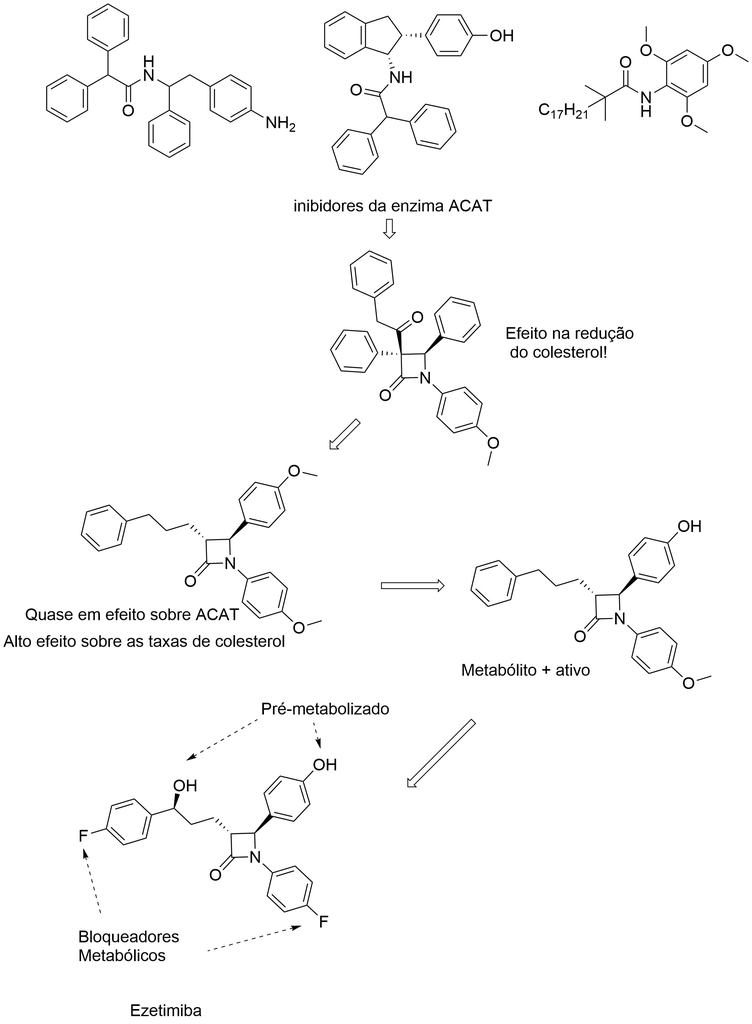

Figure 11.1: Desenvolvimento da Ezetimiba

Clinicamente, a principal vantagem da ezetimiba é seu mecanismo de ação único e complementar às estatinas. Ela inibe seletivamente a absorção de colesterol no intestino ao bloquear a proteína NPC1L1. Como as estatinas (que inibem a produção de colesterol) induzem um aumento compensatório na absorção de colesterol, a terapia combinada é altamente sinérgica, levando a reduções adicionais de LDL-C de 15 a 18% em média, e permitindo que mais pacientes atinjam metas rigorosas de LDL-C. Além disso, é bem tolerada e não é metabolizada pelo sistema P450, o que reduz o risco de interações medicamentosas e não aumenta significativamente a incidência de miopatia ou toxicidade hepática quando usada com estatinas. A maior desvantagem da ezetimiba foi a controvérsia gerada por estudos como o ENHANCE e o ARBITER 6, que, apesar de confirmarem a redução de LDL-C, falharam em demonstrar um benefício adicional na redução da progressão da aterosclerose carotídea (um desfecho substituto), lançando dúvidas sobre seu benefício clínico real. Embora preocupações iniciais sobre risco de câncer tenham sido refutadas por estudos maiores , essa controvérsia inicial afetou sua percepção clínica por anos.

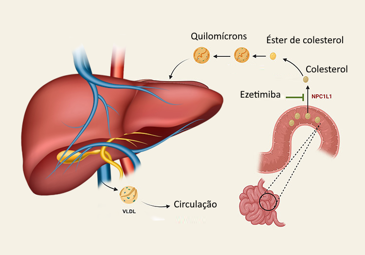

Figure 11.2: Mecanismo de ação da ezetimiba.

**Terapias Combinadas: Estatina + Ezetimiba + PCSK9 Inibidor** Para pacientes em verdadeira resistência à terapia, a combinação tripla de estatina de máxima dose tolerada + ezetimiba + inibidor de PCSK9 oferece redução LDL dramática. Estudos mostram que essa combinação pode alcançar reduções de 60-70% em LDL-colesterol comparado à baseline, mesmo em pacientes com hipercolesterolemia familial heterozigota ou homozigota parcial. Essa abordagem é particularmente importante no contexto de doença cardiovascular estabelecida onde metas de LDL-colesterol muito baixas (<55 mg/dL em risco muito elevado) são recomendadas por diretrizes modernas.

**Alternativas para Hipercolesterolemia Familial Homozigota Refratária** Para o pequeno número de pacientes com hipercolesterolemia familial homozigota (ausência completa de receptores de LDL funcionais), que não respondem significativamente a estatinas e inibidores de PCSK9, existem modalidades terapêuticas adicionais:

## 11.1 Ácido Bempedoico

Esperion Therapeutics, a empresa desenvolvedora, foi uma companhia de biotecnologia independente focada em desenvolvimento de terapias não-estatínicas para dislipidemia. Interessantemente, a empresa tinha histórico anterior com Pfizer: em 2008, Pfizer havia descontinuado seu programa de pesquisa em lipídios de Esperion quando adquiriu a companhia, levando à redução de focus. Entretanto, Esperion permaneceu como empresa independente dedicada ao desenvolvimento do Ácido Bempedóico.

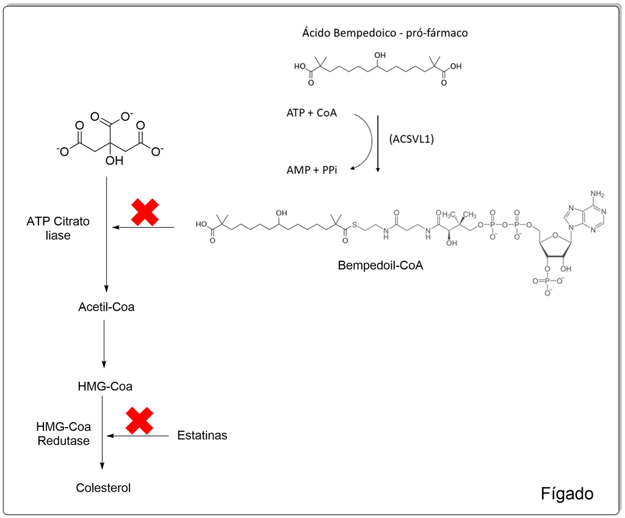

Figure 11.3: Mecanismo de ação do Ácido Bempedóico.

O mecanismo racional de design envolveu identificar e inibir a enzima ATP citrato liase (ACL), também conhecida como citrato liase ou *ADP-forming citrate-CoA ligase*, que catalisa a conversão de citrato a acetil-CoA citosólico—a etapa inicial e fundacional para síntese de ambos colesterol e ácidos graxos no fígado. Ao atuar em nível upstream de HMG-CoA redutase, bempedoic acid oferecia potencial para: (1) complementar mecanismo de estatinas oferecendo redução aditiva de LDL-colesterol; (2) atuar em pacientes intolerantes a estatinas através de mecanismo distinto; (3) evitar os efeitos miotóxicos que acometem o músculo esquelético com estatinas, porque ATP citrato liase está expressa preferencialmente no fígado, não em células musculares esqueléticas.

# 12 Inibidores e Moduladores da via de PCSK9

## 12.1 Evolocumab e Alirocumab

Os inibidores de PCSK9 (Proprotein Convertase Subtilisin/Kexin type 9) representam a classe mais estabelecida de terapia não-estatínica aprovada no Brasil. Evolucomabe (Repatha®) e alirocumabe (Praluent®) são anticorpos monoclonais humanizados completamente que se ligam à PCSK9 circulante, inibindo sua interação com os receptores de LDL hepatócitos, prevenindo a degradação desses receptores e permitindo reciclagem aumentada para a superfície celular. Ambos os medicamentos são administrados via injeção subcutânea—evolucomabe a cada 2 semanas (140 mg) ou mensalmente (420 mg), e alirocumab a cada 2 semanas (75-150 mg) ou mensalmente (300 mg)—reduzindo LDL-colesterol por aproximadamente 50-60% quando adicionados a estatinas de alto potencial ou como monoterapia em pacientes intolerantes a estatinas. Metanálises recentes demonstraram que evolocumab e alirocumab reduzem LDL-colesterol em 49.59% (95% IC −55.5%, −43.67%) comparado a placebo, também reduzindo lipoproteína(a) [Lp(a)], triglicerídeos e apolipoproteína B significativamente, mantendo perfil seguro comparable a placebo para eventos neurológicos, diabetes ou neoplasia. Os inibidores de PCSK9 são particularmente indicados para: pacientes com hipercolesterolemia familial heterozigota ou homozigota que não atingem meta com estatinas; pacientes com doença cardiovascular aterosclerótica estabelecida com LDL residual elevado; pacientes intolerantes a estatinas; e pacientes já em terapia dupla com estatina + ezetimiba que necessitam redução LDL adicional.

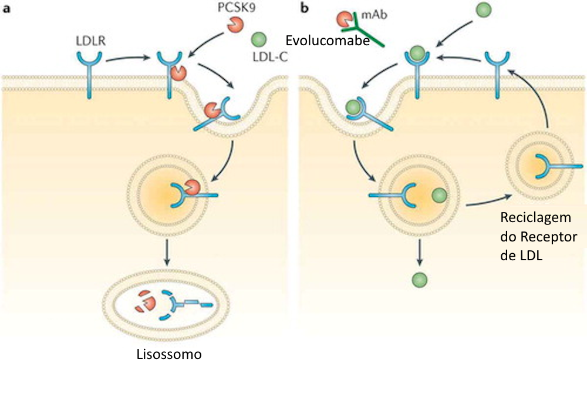

Figure 12.1: Mecanismo de ação dos inibidores de PCSK9.

## 12.2 A Inclisirana

A inclisirana (Inclisiran) foi desenvolvida para resolver um problema central no tratamento da hipercolesterolemia: a falta de adesão e a dificuldade de muitos pacientes em atingir as metas de colesterol LDL (LDL-C), mesmo com o uso de estatinas. Níveis elevados de LDL-C são a principal causa da doença cardiovascular aterosclerótica (ASCVD). Embora as estatinas e outros medicamentos existam, barreiras como a má adesão à terapia, inércia clínica, preocupações com efeitos colaterais e custos impedem que a maioria dos pacientes de alto risco atinja suas metas de LDL-C.

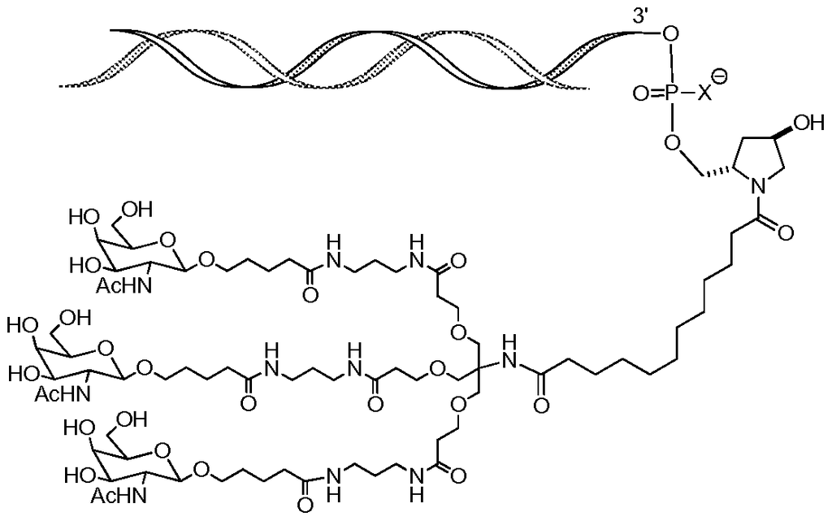

Figure 12.2: A figura ilustra a estrutura molecular da inclisirana, que consiste em duas partes principais: siRNA (Topo): A hélice de fita dupla representa o pequeno RNA de interferência (siRNA), que é a parte ativa do medicamento. Conjugado GalNAc (Inferior): A estrutura complexa na parte inferior é um ligante de N-acetilgalactosamina (GalNAc) “triantenário” (com três ramos). Este conjugado GalNAc está ligado quimicamente à extremidade 3’ da fita “passageira” (sense strand) do siRNA. O objetivo deste design é o direcionamento ao fígado: as três unidades de GalNAc são reconhecidas e ligam-se com alta afinidade aos receptores de asialoglicoproteína (ASGPR), que são abundantemente expressos quase exclusivamente na superfície das células hepáticas (hepatócitos). Isso garante que a inclisirana seja absorvida de forma rápida e específica pelo fígado após a administração subcutânea.

A história da inclisirana começa com duas descobertas científicas cruciais: a identificação do processo natural de interferência de RNA (RNAi) (que ganhou o Prêmio Nobel em 2006) e a descoberta, em 2003, do gene PCSK9. Estudos genéticos revelaram que **mutações que aumentavam a função do PCSK9 causavam hipercolesterolemia familiar**, enquanto **mutações que inativavam o PCSK9** resultavam em LDL-C muito baixo e proteção significativa contra doenças cardíacas. Isso tornou o PCSK9 um alvo terapêutico ideal.

Enquanto os anticorpos monoclonais (como evolocumabe e alirocumabe) foram desenvolvidos para bloquear a proteína PCSK9 fora da célula, a inclisirana foi projetada para usar o RNAi para impedir que a proteína fosse fabricada em primeiro lugar. O desafio tecnológico era entregar o RNAi (neste caso, um pequeno RNA de interferência, ou siRNA) especificamente ao fígado.

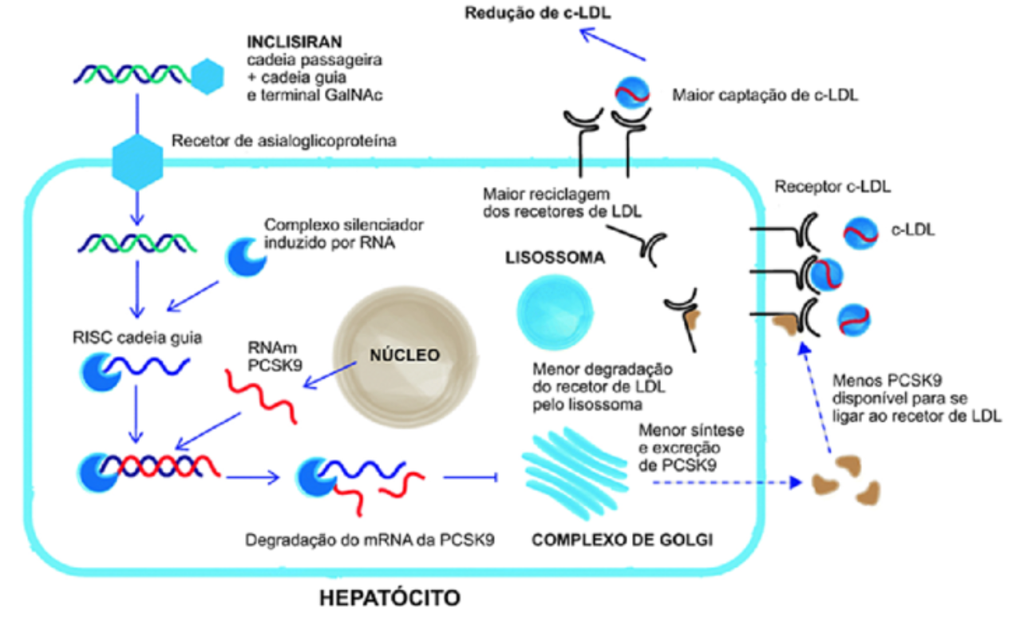

Figure 12.3: A figura ilustra como a inclisirana, uma terapia de RNA de interferência (siRNA), atua dentro da célula do fígado (hepatócito) para reduzir o colesterol LDL (c-LDL). Entrada na Célula: A inclisirana, que possui um terminal GalNAc, liga-se especificamente ao receptor de asialoglicoproteína na superfície do hepatócito, permitindo sua entrada na célula. Ativação do RISC: Uma vez dentro, a inclisirana é processada e sua “cadeia guia” é carregada no Complexo Silenciador Induzido por RNA (RISC). Silenciamento do Gene: O complexo RISC utiliza a cadeia guia para encontrar e se ligar ao RNA mensageiro (RNAm) da PCSK9 (produzido pelo núcleo). Essa ligação provoca a degradação (destruição) do RNAm. Redução da PCSK9: Sem o RNAm, o Complexo de Golgi não pode produzir e secretar a proteína PCSK9. Isso resulta em “Menor síntese e excreção de PCSK9”. Aumento dos Receptores: Com menos proteína PCSK9 fora da célula, os receptores de LDL não são marcados para degradação pelo lisossoma. Reciclagem e Captação: Isso permite uma “Maior reciclagem dos receptores de LDL” de volta à superfície da célula, onde eles podem realizar uma “Maior captação de c-LDL” do sangue. Resultado Final: O aumento da captação de c-LDL pelo fígado leva à “Redução de c-LDL” nos níveis sanguíneos.

A grande inovação foi a conjugação GalNAc. Os cientistas ligaram o siRNA a carboidratos (N-acetilgalactosamina) que agem como uma “chave-mestra”. Esses carboidratos são reconhecidos pelos receptores ASGPR, que existem quase exclusivamente na superfície das células do fígado (hepatócitos). Isso permite que o medicamento seja entregue de forma precisa e eficiente ao fígado após uma simples injeção subcutânea. Uma vez dentro da célula hepática, o siRNA direciona a quebra do mRNA do PCSK9, “silenciando” o gene e impedindo a síntese da proteína.

Dose e Adesão: Esta é a maior vantagem da inclisirana. Após as doses iniciais (dia 1 e dia 90), ela é administrada como uma injeção subcutânea de manutenção apenas duas vezes por ano (a cada 6 meses). Como é administrada por um profissional de saúde, ela resolve o problema da má adesão do paciente, uma barreira comum com medicamentos auto-injetáveis (como os anticorpos monoclonais, que são quinzenais ou mensais).

Eficácia Robusta e Sustentada: O medicamento proporciona uma redução potente e duradoura do LDL-C. Ensaios clínicos mostraram uma redução média do LDL-C de aproximadamente 50% a 52% em comparação com o placebo, quando adicionado à terapia com estatina.

Custo e Acesso: Como outras terapias biológicas avançadas, o custo elevado e a complexidade para obter autorização e reembolso do seguro de saúde são barreiras significativas para o seu uso generalizado.

## 12.3 Peptídeos Macrocíclicos Orais: A Enlicitida

A evolução das terapias direcionadas à via da PCSK9 (proproteína convertase subtilisina/kexina tipo 9) ilustra de forma magnífica o avanço tecnológico da Química Farmacêutica moderna. Inicialmente, o bloqueio da interação entre a PCSK9 e o receptor de LDL (LDL-R) era considerado uma tarefa exclusiva de anticorpos monoclonais (mAbs), como o alirocumabe e o evolocumabe, ou terapias de silenciamento gênico por siRNA (inclisirana) . Isso ocorria devido à natureza desafiadora do alvo: uma interface de interação proteína-proteína (PPI) ampla, plana e sem cavidades profundas adequadas para a acomodação de pequenas moléculas clássicas.

No entanto, o uso de biológicos injetáveis impõe limitações em termos de conveniência ao paciente e custo. A enlicitida (MK-0616) surge como um marco disruptivo ao se tornar o primeiro peptídeo macrocíclico sintético de administração oral capaz de inibir a PCSK9 com potência picomolar equivalente à dos anticorpos monoclonais, mas com cerca de 1/100 do seu peso molecular.

O ponto de partida para o desenvolvimento da enlicitida foi o composto 1a, um peptídeo cíclico obtido por meio de técnicas de biologia molecular (mRNA display). Embora o composto 1a apresentasse uma afinidade de ligação picomolar primorosa com a PCSK9, sua estrutura molecular possuía diversas características que impossibilitavam o seu avanço clínico e manufatura em larga escala:

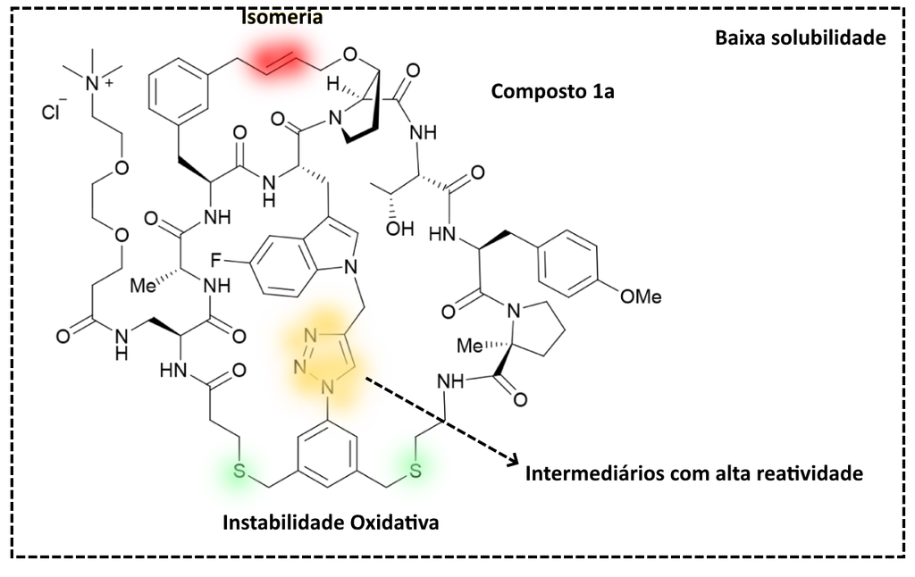

Figure 12.4: Composto 1a, muito promissor para o bloqueio de sítios planos da interação PCSK9 e fármaco

Para transformar o composto 1a em um candidato clínico viável, a equipe de químicos medicinais traçou uma estratégia de otimização multivetorial, sintetizando fragmentos modulares em solução para acelerar o ciclo DMTA (Design-Make-Test-Analyze).

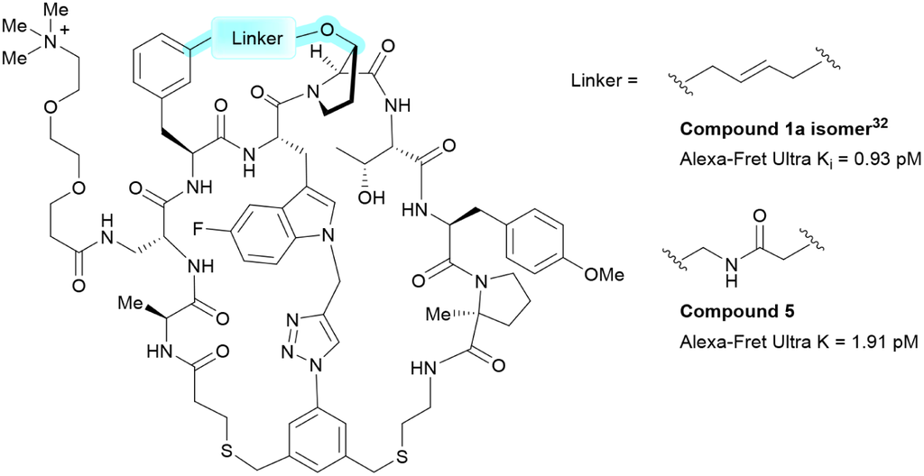

Figure 12.5: Simplificação de isômeros, problema 2

Para restaurar a rigidez conformacional do esqueleto peptídico (essencial para a afinidade picomolar), os químicos medicinais utilizaram uma estratégia de metátese de fechamento de anel (RCM - Ring-Closing Metathesis). A reação gerou uma ligação cruzada de alquila ou alcenila entre o nitrogênio indol do 7-fluorotriptofano e o nitrogênio da N-benzilamida sul. Essa abordagem de double cross-link mimetizou perfeitamente a trajetória molecular do antigo triazol e do dissulfeto (Problema 3), eliminando o risco industrial associado aos intermediários azida. Estudos de encurtamento da cadeia de RCM (variando de C6 a C4 carbonos) revelaram que a otimização conformacional alcançava o ápice de afinidade com ligantes de 4 a 5 carbonos (Composto 12), apresentando Ki na faixa de sub-picomolar (Ki ~0,78 pM para o Composto 12) Figure 12.6.

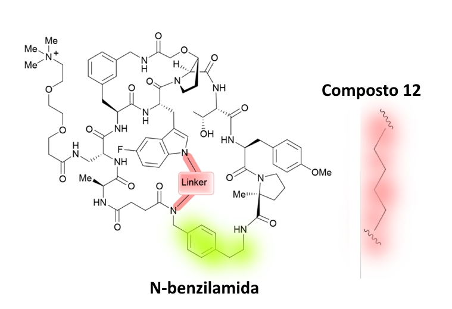

Figure 12.6: Composto 12 criado para manter alta afinidade mas sem os problemas 1 e 3

As modificações estruturais anteriores, embora tenham resolvido os problemas de estabilidade e manufatura, mantiveram a molécula altamente lipofílica. A baixa solubilidade continuava a ser o principal obstáculo para a absorção oral.

Investigações baseadas em cristalografia de raios X revelaram que a porção oeste do peptídeo macrocíclico (que contém o resíduo D-Dap) fica direcionada para o solvente e não realiza contatos diretos com a superfície da PCSK9.

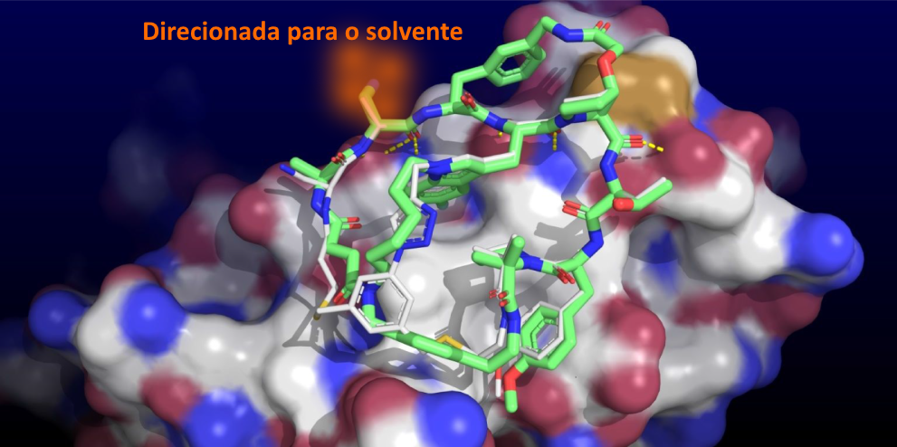

Figure 12.7: Contato imperfeito com a superfície de PCSK9

Valendo-se desse achado de modelagem molecular, os pesquisadores introduziram uma cauda de solubilização contendo um grupo amônio quaternário carregado positivamente conectado a esse resíduo (D-Dap). O amônio quaternário, por estar permanentemente ionizado em qualquer faixa de pH fisiológico, promoveu uma hidratação espetacular da molécula Figure 12.8:

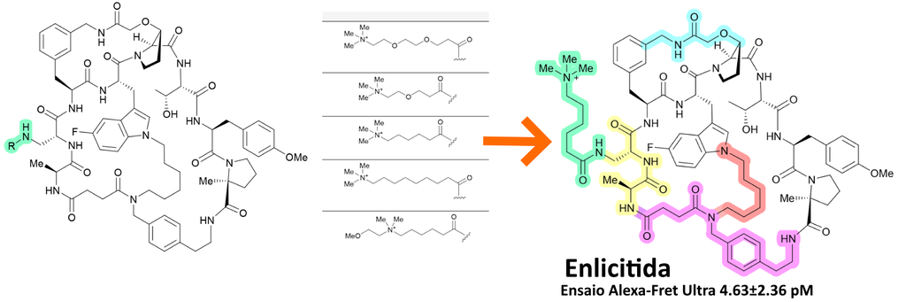

Figure 12.8: Composto final otimizado Inlicitida

Solubilidade da Enlicitida (Sal Cloreto): Aumentou para ~9,0 mg/mL de forma homogênea em toda a faixa de pH gastrointestinal (pH 2 a 10) e fluidos intestinais simulados (FaSSIF e FeSSIF). Comparação: O composto progenitor 1a apresentava solubilidade de apenas 0,15 mg/mL. A conservação geométrica e a ausência de impedimento estérico dessa cauda na ligação à PCSK9 foram confirmadas por estudos de sobreposição cristalográfica.

## 12.4 Estudos farmacocinéticos e farmacodinâmicos

Estabilidade Metabólica: A enlicitida provou ser altamente estável, sendo excretada de forma totalmente intacta na urina, sem qualquer biotransformação detectável pelo fígado. Efeitos Pleiotrópicos (função endotelial, reduzir a inflamação e estabilizar as placas ateroscleróticas) e Seletividade: Diferente de pequenas moléculas tradicionais, o tamanho peptídico garantiu uma seletividade extraordinária pela PCSK9 (comprovada em ensaios robustos do tipo PanLabs), resultando em ausência total de imunogenicidade ou toxicidade off-target.

Eficácia In Vivo: Em macacos cinomólgus (modelo translacional de excelência), uma única administração oral de enlicitida associada ao caprato de sódio inibiu rapidamente a PCSK9 livre plasmática e promoveu uma redução robusta e dose-dependente de até 46% nos níveis de colesterol LDL.

Benchmark com Anticorpos: Estudos in vitro em plasma humano comprovaram que a enlicitida possui exatamente a mesma eficácia inibidora que os anticorpos evolocumabe e alirocumabe, compartilhando inclusive o mesmo epítopo competitivo de ligação ao LDL-R em relação ao alirocumabe.

# 13 Lomitapida: Bloqueador de Proteína Transferidora de Triglicerídeos Microssomal

A história da lomitapida começa fundamentalmente com a descoberta da Proteína Transferidora de Triglicerídeos Microssomal (MTP) e sua função crítica no metabolismo de lipoproteínas. A MTP foi identificada como uma proteína heterodimérica localizada no lúmen do retículo endoplasmático de hepatócitos (células do fígado) e enterócitos (células do intestino). Sua função é catalisar o transporte de lipídios — triglicerídeos (TG), ésteres de colesterol (CE) e fosfatidilcolina (PC) — entre as membranas.

Esta função de transporte é absolutamente essencial para a montagem de lipoproteínas contendo apolipoproteína B (apoB). Estudos genéticos demonstraram que a ausência de MTP funcional é a causa da abetalipoproteinemia, uma doença rara onde os pacientes não conseguem montar e secretar lipoproteínas contendo apoB. Isso confirmou que a MTP é necessária para a síntese de VLDL (lipoproteína de muito baixa densidade) no fígado e de quilomícrons no intestino.

Um dos primeiros compostos identificados foi BMS-200150 (2-[1-(3,3-difenilpropil)-4-piperidinila]-2,3-dihidro-1H-isoindol-1-ona), um antagonista de MTP que demonstrou capacidade de reduzir colesterol e triglicerídeos em modelos animais ao bloquear a secreção de VLDL e quilomícrons. Posteriormente, CP-346086 (um inibidor de MTP identificado por Pfizer) foi avaliado em estudos in vitro e em animais experimentais, demonstrando redução dose-dependente de colesterol (23-75% dependendo da dose) e triglicerídeos (33-62%) em roedores. Estes estudos proof-of-concept mostraram que inibição farmacológica de MTP era viável e resultava em redução lipídica significativa.

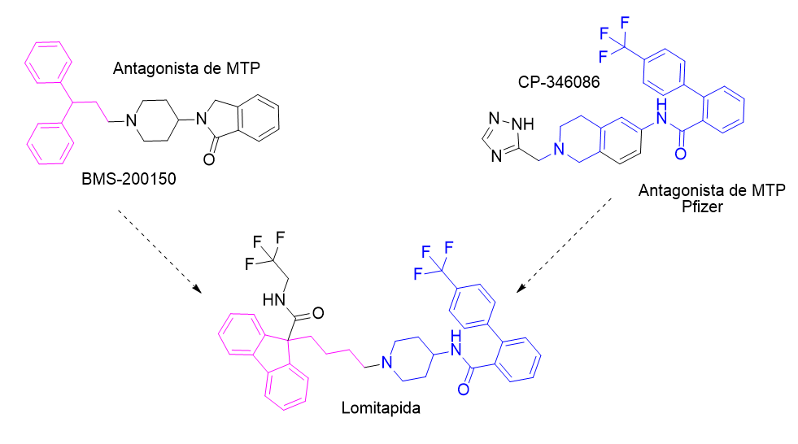

Figure 13.1: Planejamento da Lomitapida.

Esta pesquisa fundamental levou ao desenvolvimento da lomitapida, um potente inibidor da MTP. O desenvolvimento clínico foi direcionado a uma lacuna crítica: pacientes com **Hipercolesterolemia Familiar Homozigota (HoFH)**. A HoFH é uma doença genética rara causada por mutações em ambos os alelos do gene do receptor de LDL (LDL-R) . Como esses pacientes não possuem receptores de LDL funcionais, as terapias padrão (como as estatinas, que dependem do LDL-R) são insuficientes. A lomitapida foi desenvolvida como uma terapia **independente do receptor de LDL**, oferecendo uma solução para essa necessidade clínica não atendida.

### 13.0.1 Mecanismo de ação

O mecanismo de ação da lomitapida é a inibição direta da Proteína Transferidora de Triglicerídeos Microssomal (MTP).

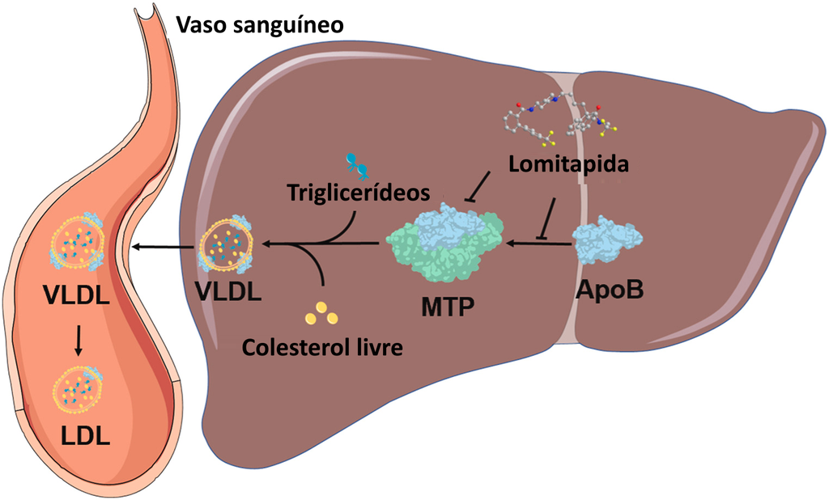

Figure 13.2: A figura ilustra o mecanismo pelo qual a lomitapida reduz o colesterol, atuando diretamente no fígado (hepatócito): Montagem Normal do VLDL: No fígado, a enzima MTP (Proteína Transferidora de Triglicerídeos Microssomal) é essencial. Ela age “carregando” lipídios, como Triglicerídeos e Colesterol livre, para a ApoB (Apolipoproteína B), montando assim a partícula de VLDL (lipoproteína de muito baixa densidade). Secreção e Conversão: O VLDL montado é então secretado pelo fígado no vaso sanguíneo. Na corrente sanguínea, o VLDL é convertido em LDL (“colesterol ruim”). Inibição pela Lomitapida: A Lomitapida atua como um inibidor direto, bloqueando a função da MTP. Resultado: Ao inibir a MTP, a lomitapida impede a montagem e a secreção de VLDL pelo fígado. Isso interrompe a produção de VLDL e, consequentemente, reduz drasticamente a quantidade de LDL no sangue.

- Bloqueio da Montagem: A MTP é uma proteína-chave no fígado e no intestino, responsável por carregar lipídios (triglicerídeos e colesterol) para a apolipoproteína B (apoB) durante sua síntese no retículo endoplasmático.
- Inibição da Secreção: Ao inibir a MTP, a lomitapida impede a “lipidação” da apoB. Sem essa carga lipídica, as partículas de VLDL (no fígado) e os quilomícrons (no intestino) não podem ser montadas corretamente.
- Redução de Lipoproteínas: Como resultado, a secreção de VLDL e quilomícrons na corrente sanguínea é drasticamente reduzida. Dado que o LDL-C é um produto do metabolismo do VLDL, a redução na produção de VLDL leva diretamente a uma queda acentuada nos níveis de LDL-C e apoB no plasma.

Este mecanismo é notável por ser totalmente independente dos receptores de LDL na superfície celular.

## 13.1 Considerações finais

Enquanto comunidade médica alcançou sucesso extraordinário em redução de LDL-C através de escalação de terapias desde estatinas → inibidores PCSK9 → inclisiran, grandes objetivos não-alcançados permanecem: manejo de Lipoproteína(a), aderência crônica a terapia, eliminação de risco residual além de lipídios, regressão de placa estabelecida, equidade global de acesso, terapias genéticas permanentes, e determinantes sociais de saúde. A próxima década provavelmente testemunhará transição de foco de “quantidades de redução de colesterol” para “qualidade de estabilização vascular”, “eliminação de risco residual multifatorial”, e “tratamentos curativos únicos através de genética somática.”